# Titanic

# The Challenge

*The sinking of the Titanic is one of the most infamous shipwrecks in history.*

*On April 15, 1912, during her maiden voyage, the widely considered “unsinkable” RMS Titanic sank after colliding with an iceberg. Unfortunately, there weren’t enough lifeboats for everyone onboard, resulting in the death of 1502 out of 2224 passengers and crew.*

*While there was some element of luck involved in surviving, it seems some groups of people were more likely to survive than others.*

*In this challenge, we ask you to build a predictive model that answers the question: “what sorts of people were more likely to survive?” using passenger data (ie name, age, gender, socio-economic class, etc). - kaggle*

I’m going to use the logistic regression since the data can be submitted as if each passenger would be survive the accidents (survived = 1, dead = 0).

```r
library(pROC)
train = read.csv('train.csv', header = T)
rows = sample(1:nrow(train), nrow(train)*0.3)
df = train[rows,]
test = train[-rows,]
# To match logit function values, run
df = train
```

**To match logit function values, run df = train**

# Variable Analytics

## Ticket Class (Pclass)

Noted as aproxy socio-economic status (1 = high, 3 = low)

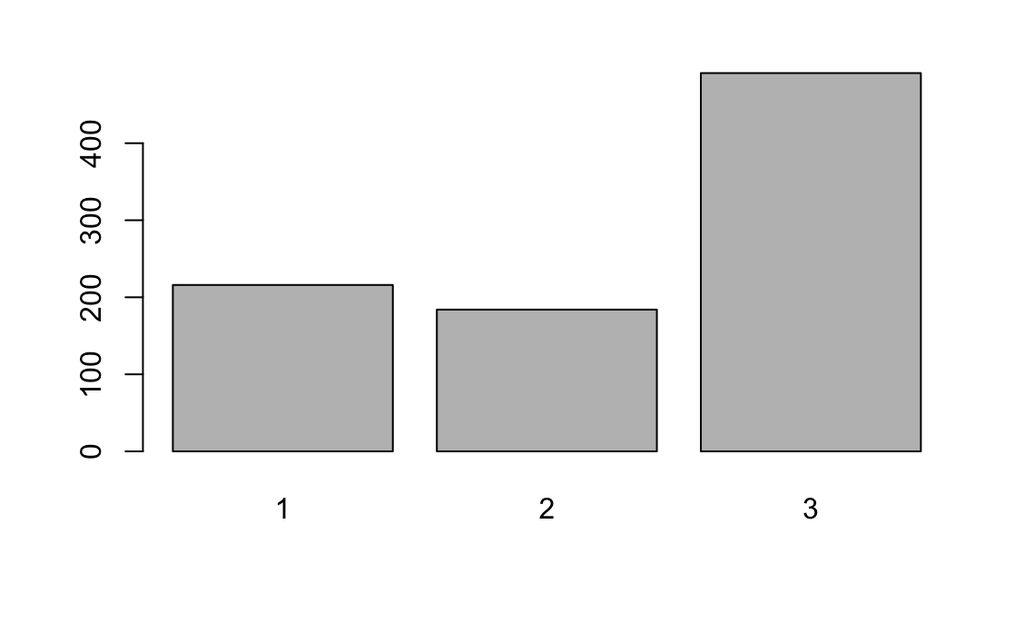

```r
barplot(table(df$Pclass))
```

I don’t know how much price difference between 1,2, and 3, so test them if I can use it as quantitative as is, or I need to add some weight on the class.

```r
fit = glm(Survived~Pclass, family = binomial, data = df)
summary(fit)
```

```
Call:
glm(formula = Survived ~ Pclass, family = binomial, data = df)

Deviance Residuals:
    Min       1Q   Median       3Q      Max
-1.4390  -0.7569  -0.7569   0.9367   1.6673

Coefficients:
            Estimate Std. Error z value Pr(>|z|)
(Intercept)  1.44679    0.20743   6.975 3.06e-12 ***
Pclass      -0.85011    0.08715  -9.755  < 2e-16 ***
---
Signif. codes:  0 ‘***’ 0.001 ‘**’ 0.01 ‘*’ 0.05 ‘.’ 0.1 ‘ ’ 1

(Dispersion parameter for binomial family taken to be 1)

    Null deviance: 1186.7  on 890  degrees of freedom
Residual deviance: 1084.4  on 889  degrees of freedom
AIC: 1088.4

Number of Fisher Scoring iterations: 4
```

```r
fit2 = glm(Survived~factor(Pclass), family = binomial, data = df)
summary(fit2)
```

```
Call:
glm(formula = Survived ~ factor(Pclass), family = binomial, data = df)

Deviance Residuals:
    Min       1Q   Median       3Q      Max
-1.4094  -0.7450  -0.7450   0.9619   1.6836

Coefficients:
                Estimate Std. Error z value Pr(>|z|)
(Intercept)       0.5306     0.1409   3.766 0.000166 ***
factor(Pclass)2  -0.6394     0.2041  -3.133 0.001731 **
factor(Pclass)3  -1.6704     0.1759  -9.496  < 2e-16 ***
---
Signif. codes:  0 ‘***’ 0.001 ‘**’ 0.01 ‘*’ 0.05 ‘.’ 0.1 ‘ ’ 1

(Dispersion parameter for binomial family taken to be 1)

    Null deviance: 1186.7  on 890  degrees of freedom
Residual deviance: 1083.1  on 888  degrees of freedom
AIC: 1089.1

Number of Fisher Scoring iterations: 4
```

Likelihood Ration Test(LRT)

```r
LRT = summary(fit)$deviance - summary(fit2)$deviance
delta = 889 - 888
p_val = 1 - pchisq(LRT, delta)
p_val
```

```
[1] 0.2553934
```

$logit(π) = 1.44679 - 0.85011p $

## sex

No doubt it affects surviving status.

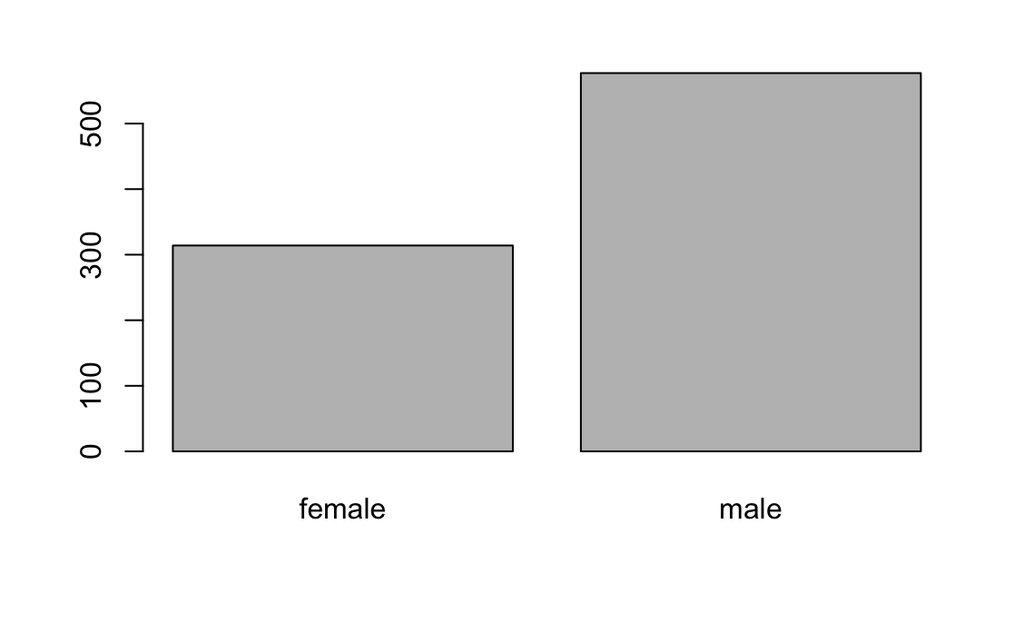

```r
val = df$Sex
barplot(table(val))
```

See if different gender in different ticket class have vary surviving rate.

```r
fit_ge = glm(Survived~Pclass*Sex, family = binomial ,data = df)
summary(fit_ge)
```

```
Call:
glm(formula = Survived ~ Pclass * Sex, family = binomial, data = df)

Deviance Residuals:
    Min       1Q   Median       3Q      Max
-2.8488  -0.6969  -0.5199   0.4946   2.0339

Coefficients:
               Estimate Std. Error z value Pr(>|z|)
(Intercept)      6.0416     0.8273   7.303 2.81e-13 ***
Pclass          -2.0011     0.2950  -6.784 1.17e-11 ***
Sexmale         -6.0493     0.8756  -6.909 4.88e-12 ***
Pclass:Sexmale   1.3593     0.3202   4.245 2.19e-05 ***
---
Signif. codes:  0 ‘***’ 0.001 ‘**’ 0.01 ‘*’ 0.05 ‘.’ 0.1 ‘ ’ 1

(Dispersion parameter for binomial family taken to be 1)

    Null deviance: 1186.66  on 890  degrees of freedom
Residual deviance:  803.12  on 887  degrees of freedom
AIC: 811.12

Number of Fisher Scoring iterations: 6
```

Probably,

```r
fit_ge = glm(Survived~Pclass + Sex, family = binomial ,data = df)
summary(fit_ge)
```

```
Call:
glm(formula = Survived ~ Pclass + Sex, family = binomial, data = df)

Deviance Residuals:
    Min       1Q   Median       3Q      Max
-2.2030  -0.7036  -0.4519   0.6719   2.1599

Coefficients:
            Estimate Std. Error z value Pr(>|z|)
(Intercept)   3.2946     0.2974  11.077   <2e-16 ***
Pclass       -0.9606     0.1061  -9.057   <2e-16 ***
Sexmale      -2.6434     0.1838 -14.380   <2e-16 ***
---
Signif. codes:  0 ‘***’ 0.001 ‘**’ 0.01 ‘*’ 0.05 ‘.’ 0.1 ‘ ’ 1

(Dispersion parameter for binomial family taken to be 1)

    Null deviance: 1186.7  on 890  degrees of freedom
Residual deviance:  827.2  on 888  degrees of freedom
AIC: 833.2

Number of Fisher Scoring iterations: 4
```

Just seeing at AIC, go with model with interaction (Pclass:Sex) $logit(π) = 6.0416 -2.0011p -6.0493s + 1.3593ps$

## Age

No doubt it affects surviving status.

```r
val = df$Age
summary(val)
```

```
   Min. 1st Qu.  Median    Mean 3rd Qu.    Max.    NA's
   0.42   20.12   28.00   29.70   38.00   80.00     177
```

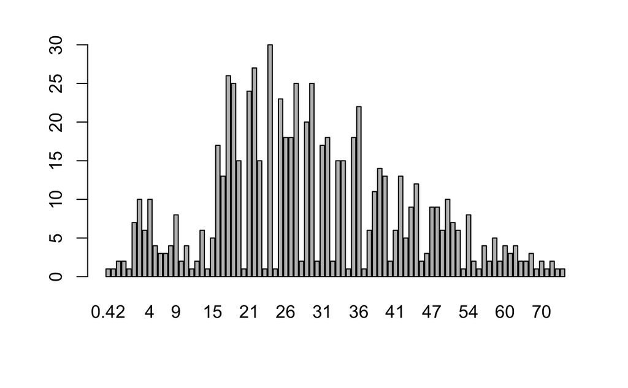

```r
barplot(table(val))
```

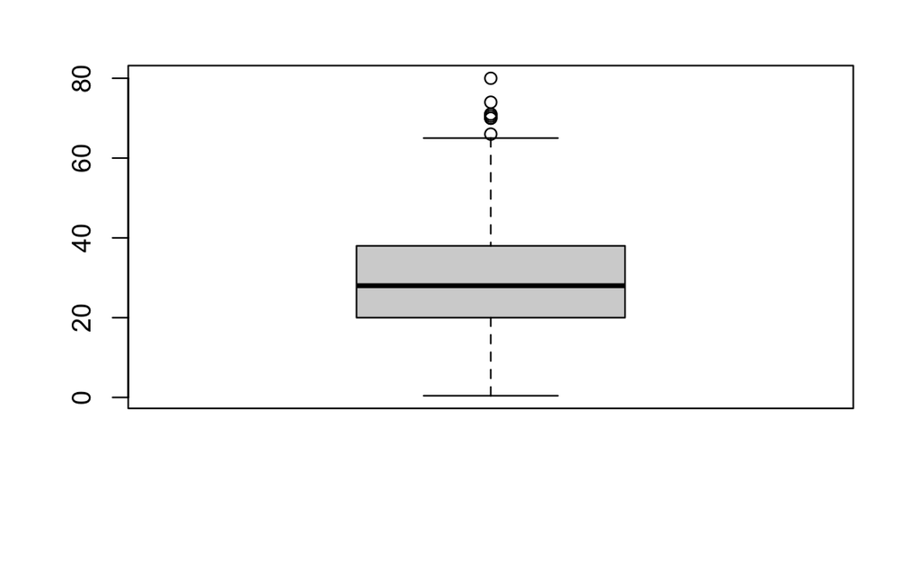

```r
boxplot(val)
```

Test interaction Age and Pclass

```r
fit5 = glm(Survived~Pclass*Sex+ Age, family = binomial ,data = df)
summary(fit5)
```

```
Call:
glm(formula = Survived ~ Pclass * Sex + Age, family = binomial,
    data = df)

Deviance Residuals:
    Min       1Q   Median       3Q      Max
-3.3110  -0.6883  -0.4610   0.4793   2.3408

Coefficients:
                Estimate Std. Error z value Pr(>|z|)
(Intercept)     7.964377   0.969104   8.218  < 2e-16 ***
Pclass         -2.410212   0.328766  -7.331 2.28e-13 ***
Sexmale        -6.115491   0.928679  -6.585 4.54e-11 ***
Age            -0.038445   0.007913  -4.859 1.18e-06 ***
Pclass:Sexmale  1.479637   0.348465   4.246 2.17e-05 ***
---
Signif. codes:  0 ‘***’ 0.001 ‘**’ 0.01 ‘*’ 0.05 ‘.’ 0.1 ‘ ’ 1

(Dispersion parameter for binomial family taken to be 1)

    Null deviance: 964.52  on 713  degrees of freedom
Residual deviance: 623.99  on 709  degrees of freedom
  (177 observations deleted due to missingness)
AIC: 633.99

Number of Fisher Scoring iterations: 6
```

```r
fit_int = glm(Survived~Pclass*Sex+ Pclass*Age, family = binomial ,data = df)
summary(fit_int)
```

```
Call:
glm(formula = Survived ~ Pclass * Sex + Pclass * Age, family = binomial,
    data = df)

Deviance Residuals:
    Min       1Q   Median       3Q      Max
-3.2706  -0.6896  -0.4568   0.4835   2.3701

Coefficients:
                Estimate Std. Error z value Pr(>|z|)
(Intercept)     7.709898   1.113964   6.921 4.48e-12 ***
Pclass         -2.298666   0.408510  -5.627 1.83e-08 ***
Sexmale        -6.160221   0.938520  -6.564 5.25e-11 ***
Age            -0.029716   0.020474  -1.451    0.147
Pclass:Sexmale  1.498049   0.352569   4.249 2.15e-05 ***
Pclass:Age     -0.004127   0.008975  -0.460    0.646
---
Signif. codes:  0 ‘***’ 0.001 ‘**’ 0.01 ‘*’ 0.05 ‘.’ 0.1 ‘ ’ 1

(Dispersion parameter for binomial family taken to be 1)

    Null deviance: 964.52  on 713  degrees of freedom
Residual deviance: 623.78  on 708  degrees of freedom
  (177 observations deleted due to missingness)
AIC: 635.78

Number of Fisher Scoring iterations: 6
```

No interaction needed among Pclass and Age (Based on AIC)

$logit(π) = 7.964377-2.410212p -6.115491 s -0.038445a + 1.479637 ps$

## # of siblings / spouses aboard the Titanic (SibSp)

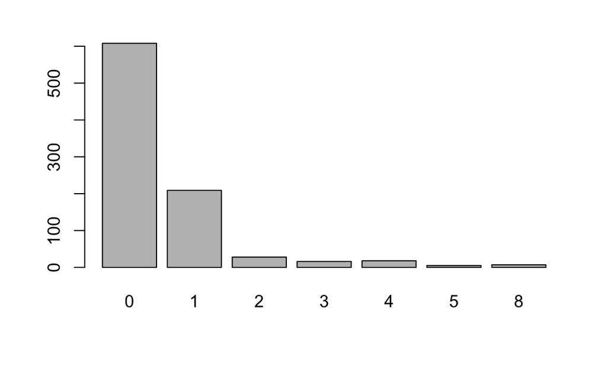

```r
barplot(table(df$SibSp))
```

```r
fit6 = glm(Survived~Pclass*Sex+ Age + SibSp, family = binomial ,data = df)
summary(fit6)
```

```
Call:
glm(formula = Survived ~ Pclass * Sex + Age + SibSp, family = binomial,
    data = df)

Deviance Residuals:
    Min       1Q   Median       3Q      Max
-3.3507  -0.6574  -0.4438   0.4532   2.3450

Coefficients:
                Estimate Std. Error z value Pr(>|z|)
(Intercept)     8.487528   0.996601   8.516  < 2e-16 ***
Pclass         -2.429192   0.330221  -7.356 1.89e-13 ***
Sexmale        -6.162294   0.929696  -6.628 3.40e-11 ***
Age            -0.046830   0.008603  -5.443 5.24e-08 ***
SibSp          -0.354855   0.120373  -2.948   0.0032 **
Pclass:Sexmale  1.462084   0.349338   4.185 2.85e-05 ***
---
Signif. codes:  0 ‘***’ 0.001 ‘**’ 0.01 ‘*’ 0.05 ‘.’ 0.1 ‘ ’ 1

(Dispersion parameter for binomial family taken to be 1)

    Null deviance: 964.52  on 713  degrees of freedom
Residual deviance: 614.22  on 708  degrees of freedom
  (177 observations deleted due to missingness)
AIC: 626.22

Number of Fisher Scoring iterations: 6
```

```r
fit_sib = glm(Survived~Pclass*Sex+ Age + Pclass*SibSp, family = binomial ,data = df)
summary(fit_sib)
```

```
Call:
glm(formula = Survived ~ Pclass * Sex + Age + Pclass * SibSp,
    family = binomial, data = df)

Deviance Residuals:
    Min       1Q   Median       3Q      Max
-3.4238  -0.6570  -0.4235   0.4570   2.3314

Coefficients:
                Estimate Std. Error z value Pr(>|z|)
(Intercept)     7.983629   1.020857   7.821 5.26e-15 ***
Pclass         -2.228456   0.344762  -6.464 1.02e-10 ***
Sexmale        -5.979318   0.932516  -6.412 1.44e-10 ***
Age            -0.047154   0.008646  -5.454 4.94e-08 ***
SibSp           0.532093   0.491734   1.082   0.2792
Pclass:Sexmale  1.384513   0.352154   3.932 8.44e-05 ***
Pclass:SibSp   -0.334461   0.180880  -1.849   0.0644 .
---
Signif. codes:  0 ‘***’ 0.001 ‘**’ 0.01 ‘*’ 0.05 ‘.’ 0.1 ‘ ’ 1

(Dispersion parameter for binomial family taken to be 1)

    Null deviance: 964.52  on 713  degrees of freedom
Residual deviance: 610.72  on 707  degrees of freedom
  (177 observations deleted due to missingness)
AIC: 624.72

Number of Fisher Scoring iterations: 6
```

```r
1 - pchisq(614.22-610.72,1)
```

```
[1] 0.06136883
```

Statistically insignificant…

How about treat SibSp as factor

```r
fit_fcsib = glm(Survived~Pclass*Sex+ Age + factor(SibSp), family = binomial ,data = df)
summary(fit_fcsib)
```

```
Call:
glm(formula = Survived ~ Pclass * Sex + Age + factor(SibSp),
    family = binomial, data = df)

Deviance Residuals:
    Min       1Q   Median       3Q      Max
-3.4220  -0.6609  -0.4424   0.4538   2.3722

Coefficients:
                 Estimate Std. Error z value Pr(>|z|)
(Intercept)      8.325390   1.000403   8.322  < 2e-16 ***
Pclass          -2.390448   0.330754  -7.227 4.93e-13 ***
Sexmale         -6.115967   0.930950  -6.570 5.05e-11 ***
Age             -0.047708   0.008679  -5.497 3.86e-08 ***
factor(SibSp)1   0.012672   0.235888   0.054   0.9572
factor(SibSp)2  -0.521686   0.564398  -0.924   0.3553
factor(SibSp)3  -1.880671   0.835631  -2.251   0.0244 *
factor(SibSp)4  -1.478172   0.702680  -2.104   0.0354 *
factor(SibSp)5 -14.919698 612.600479  -0.024   0.9806
Pclass:Sexmale   1.452319   0.349733   4.153 3.29e-05 ***
---
Signif. codes:  0 ‘***’ 0.001 ‘**’ 0.01 ‘*’ 0.05 ‘.’ 0.1 ‘ ’ 1

(Dispersion parameter for binomial family taken to be 1)

    Null deviance: 964.52  on 713  degrees of freedom
Residual deviance: 609.34  on 704  degrees of freedom
  (177 observations deleted due to missingness)
AIC: 629.34

Number of Fisher Scoring iterations: 14
```

Hmmmm… Nop,

Go with fit6  
$logit(π) = 8.487528-2.429192p -6.162294s -0.046830a -0.354855s_2 +1.462084 ps$

## Ticket number (ticket)

The ticket number is unique by the ticket. There are some relation between Ticket number and ticket class; if the first desit of the ticket number is 1, the passenger are likely to have 1 for ticket class. Hence, I do not incrude it in to the model

## Passenger fare (Fare)

```r
summary(df$Fare)
```

```
   Min. 1st Qu.  Median    Mean 3rd Qu.    Max.
   0.00    7.91   14.45   32.20   31.00  512.33
```

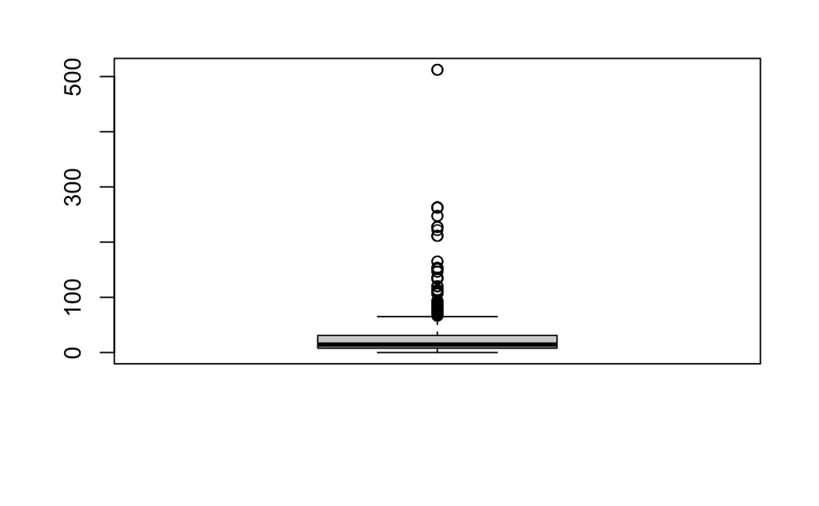

```r
boxplot(df$Fare)
```

Very skewed data, it is better to normalize. ### Taking Log Replace Fare == 0 as NA and take log otherwides.

```r
df$log_Fare = ifelse(df$Fare<= 0, NA, log(df$Fare))
summary(df$log_Fare)
```

```
   Min. 1st Qu.  Median    Mean 3rd Qu.    Max.    NA's
  1.389   2.070   2.674   2.943   3.443   6.239      15
```

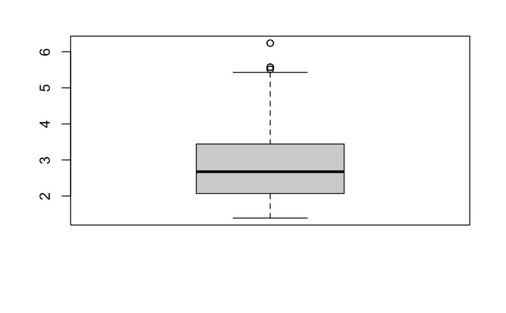

```r
boxplot(df$log_Fare)
```

```r
fit7 = glm(Survived~Pclass*Sex+ Age + SibSp + log_Fare, family = binomial ,data = df)
summary(fit7)
```

```
Call:
glm(formula = Survived ~ Pclass * Sex + Age + SibSp + log_Fare,
    family = binomial, data = df)

Deviance Residuals:
    Min       1Q   Median       3Q      Max
-3.3843  -0.6490  -0.4387   0.4652   2.3525

Coefficients:
               Estimate Std. Error z value Pr(>|z|)
(Intercept)     7.92222    1.34723   5.880 4.09e-09 ***
Pclass         -2.33900    0.36138  -6.473 9.64e-11 ***
Sexmale        -6.10425    0.94039  -6.491 8.52e-11 ***
Age            -0.04651    0.00862  -5.396 6.82e-08 ***
SibSp          -0.40003    0.13940  -2.870  0.00411 **
log_Fare        0.12613    0.20407   0.618  0.53653
Pclass:Sexmale  1.44229    0.35411   4.073 4.64e-05 ***
---
Signif. codes:  0 ‘***’ 0.001 ‘**’ 0.01 ‘*’ 0.05 ‘.’ 0.1 ‘ ’ 1

(Dispersion parameter for binomial family taken to be 1)

    Null deviance: 956.44  on 706  degrees of freedom
Residual deviance: 606.31  on 700  degrees of freedom
  (184 observations deleted due to missingness)
AIC: 620.31

Number of Fisher Scoring iterations: 6
```

Nop, did mpt work. Stick with simple model.

### Check Correlation between Fare and Ticket Class

```r
cor(df$Fare, df$Pclass)
```

```
[1] -0.5494996
```

=> Moderate Association  
As Fare increase, the Pclass decreases (Become Pclass repesent more higher class because 1 = high and 3 = low class)

Avoid multicollinality => Do not include Fare

## Cabin number (Cabin)

Seems like Cabin number is related to Fare. The same Cabin number tends to have shared fare. But there may be different cabin number with same fare, so I can not be able to concatenate Cabin number using fare as ID.

```r
fit7 = glm(Survived~Pclass*Sex+ Age + SibSp + Cabin, family = binomial ,data = df)
summary(fit7)
```

```
Call:
glm(formula = Survived ~ Pclass * Sex + Age + SibSp + Cabin,
    family = binomial, data = df)

Deviance Residuals:
    Min       1Q   Median       3Q      Max
-2.4653  -0.5857  -0.2918   0.1232   3.4239

Coefficients:
                       Estimate Std. Error z value Pr(>|z|)
(Intercept)           1.017e+01  1.424e+00   7.140 9.33e-13 ***
Pclass               -2.924e+00  4.654e-01  -6.282 3.34e-10 ***
Sexmale              -8.975e+00  1.414e+00  -6.349 2.17e-10 ***
Age                  -5.552e-02  1.119e-02  -4.961 7.01e-07 ***
SibSp                -4.367e-01  1.358e-01  -3.217 0.001297 **
CabinA10             -1.826e+01  1.075e+04  -0.002 0.998645
CabinA16              1.542e+01  1.075e+04   0.001 0.998856
CabinA20              2.203e+01  1.075e+04   0.002 0.998366
CabinA23              2.331e+01  1.075e+04   0.002 0.998270
CabinA24             -1.854e+01  1.075e+04  -0.002 0.998624
CabinA26              2.198e+01  1.075e+04   0.002 0.998369
CabinA31              2.109e+01  1.075e+04   0.002 0.998435
CabinA34              1.909e+01  1.075e+04   0.002 0.998583
CabinA36             -1.810e+01  1.075e+04  -0.002 0.998657
CabinA5              -1.632e+01  1.075e+04  -0.002 0.998789
CabinA6               2.043e+01  1.075e+04   0.002 0.998485
CabinA7              -1.715e+01  1.075e+04  -0.002 0.998727
CabinB101             2.081e+01  1.075e+04   0.002 0.998456
CabinB18              1.417e+01  7.257e+03   0.002 0.998442
CabinB19             -1.687e+01  1.075e+04  -0.002 0.998748
CabinB20              1.961e+01  5.281e+03   0.004 0.997038
CabinB22             -8.098e-01  6.599e+00  -0.123 0.902329
CabinB28              1.523e+01  7.341e+03   0.002 0.998344
CabinB3               1.471e+01  1.075e+04   0.001 0.998909
CabinB30             -1.665e+01  1.075e+04  -0.002 0.998764
CabinB35              1.365e+01  7.604e+03   0.002 0.998567
CabinB37             -1.704e+01  1.075e+04  -0.002 0.998736
CabinB38             -1.776e+01  1.075e+04  -0.002 0.998682
CabinB39              1.354e+01  1.075e+04   0.001 0.998995
CabinB4               1.476e+01  1.075e+04   0.001 0.998905
```

[output cut: 106 more lines]

```
CabinF4               1.917e+01  6.070e+03   0.003 0.997480
CabinG6              -3.654e-01  1.089e+00  -0.336 0.737181
CabinT               -1.776e+01  1.075e+04  -0.002 0.998682
Pclass:Sexmale        2.424e+00  5.081e-01   4.771 1.83e-06 ***
---
Signif. codes:  0 ‘***’ 0.001 ‘**’ 0.01 ‘*’ 0.05 ‘.’ 0.1 ‘ ’ 1

(Dispersion parameter for binomial family taken to be 1)

    Null deviance: 964.52  on 713  degrees of freedom
Residual deviance: 464.27  on 574  degrees of freedom
  (177 observations deleted due to missingness)
AIC: 744.27

Number of Fisher Scoring iterations: 18
```

CabinC22 C26 is significant by p-value, but too small sample, Do not include it in the model.

## Port of Embarkation (Embarked)

C = Cherbourg, Q = Queenstown, S = Southampton

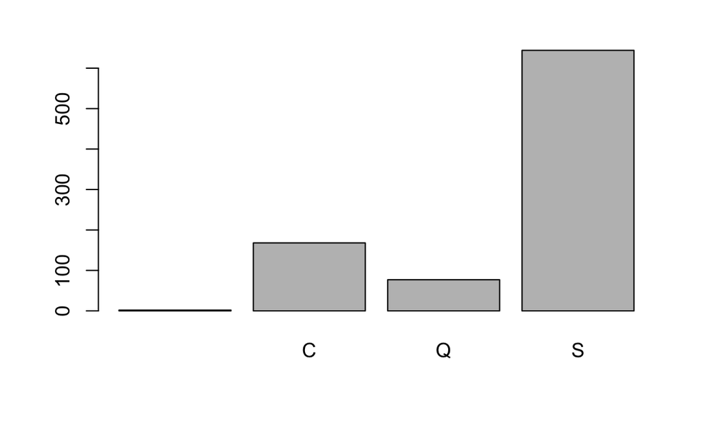

```r
barplot(table(df$Embarked))
```

```r
fit8 = glm(Survived~Pclass*Sex+ Age + SibSp + Embarked, family = binomial ,data = df)
summary(fit8)
```

```
Call:
glm(formula = Survived ~ Pclass * Sex + Age + SibSp + Embarked,
    family = binomial, data = df)

Deviance Residuals:
    Min       1Q   Median       3Q      Max
-3.3031  -0.6557  -0.4397   0.4671   2.3499

Coefficients:
                 Estimate Std. Error z value Pr(>|z|)
(Intercept)     19.310256 607.622843   0.032  0.97465
Pclass          -2.389587   0.339024  -7.048 1.81e-12 ***
Sexmale         -6.250679   0.953656  -6.554 5.59e-11 ***
Age             -0.045343   0.008635  -5.251 1.51e-07 ***
SibSp           -0.341032   0.121640  -2.804  0.00505 **
EmbarkedC      -10.523765 607.622808  -0.017  0.98618
EmbarkedQ      -11.198975 607.623009  -0.018  0.98530
EmbarkedS      -11.038009 607.622760  -0.018  0.98551
Pclass:Sexmale   1.497326   0.358757   4.174 3.00e-05 ***
---
Signif. codes:  0 ‘***’ 0.001 ‘**’ 0.01 ‘*’ 0.05 ‘.’ 0.1 ‘ ’ 1

(Dispersion parameter for binomial family taken to be 1)

    Null deviance: 964.52  on 713  degrees of freedom
Residual deviance: 610.34  on 705  degrees of freedom
  (177 observations deleted due to missingness)
AIC: 628.34

Number of Fisher Scoring iterations: 13
```

Not much improvement. Go with fit6.

## Primary model

Primary Model: $logit(π) = 8.487528-2.429192p -6.162294s -0.046830a -0.354855s_2 +1.462084 ps$ (fit6)

**But for in purpose of this competition, I should use the model with lowest AIC. But for real world, we should use the model that is simple but efficient.**

# Test my model

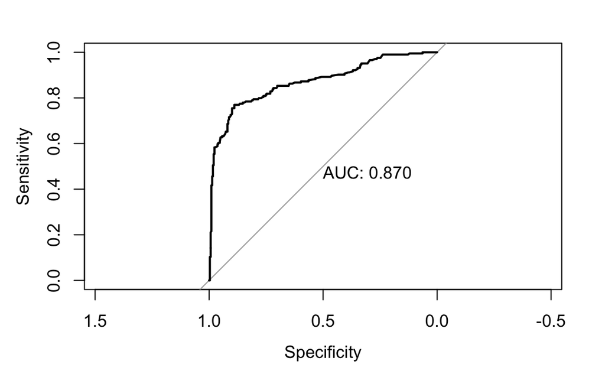

```r
prediction = predict(fit6, newdata = test, type = "response")
test_roc = pROC::roc(test$Survived ~ prediction, plot = TRUE, print.auc = TRUE)
```

## For submission

```r
fit6 = glm(Survived~Pclass*Sex+ Age + SibSp, family = binomial ,data = train)
test = read.csv('test.csv', header = T)
prediction = predict(fit6, test, type = 'response')
prediction = (prediction > 0.5)*1
prediction[is.na(prediction )] = 0
prediction
```

```
  1   2   3   4   5   6   7   8   9  10  11  12  13  14  15  16
  0   0   0   0   0   0   0   0   1   0   0   0   1   0   1   1
 17  18  19  20  21  22  23  24  25  26  27  28  29  30  31  32
  0   0   0   0   0   0   0   1   1   0   1   0   0   0   0   0
 33  34  35  36  37  38  39  40  41  42  43  44  45  46  47  48
  0   0   0   0   0   1   0   0   0   0   0   1   1   0   0   0
 49  50  51  52  53  54  55  56  57  58  59  60  61  62  63  64
  1   0   0   0   1   1   0   0   0   0   0   1   0   0   0   1
 65  66  67  68  69  70  71  72  73  74  75  76  77  78  79  80
  1   0   1   0   0   1   1   0   0   1   1   0   0   1   0   1
 81  82  83  84  85  86  87  88  89  90  91  92  93  94  95  96
  0   0   0   0   0   0   0   1   0   0   0   0   1   0   1   0
 97  98  99 100 101 102 103 104 105 106 107 108 109 110 111 112
  1   0   1   0   1   0   0   0   1   0   0   0   0   0   0   0
113 114 115 116 117 118 119 120 121 122 123 124 125 126 127 128
```

[output cut: 39 more lines]

```r
pred = data.frame(PassengerId=test$PassengerId, Survived=prediction)
write.csv(pred, 'pred_ver1.csv',row.names = FALSE)
```

# Result

## version 1

Top 21.4%  
4895th (by score 4027th) out of 18794 with score of 0.77990